# AS5_Richard Yang

Richard Yang

2023-07-15

## Question 1:

Load the condmilk.rda dataset and split it into a training dataset (1971/1 – 1979/12) and a test dataset (1980/1 – 1980/12)

```r
# Load the required packages
library(readxl)
library(ggplot2)
library(fpp)
library(TSA)
library(forecast)
library(reshape)
library(DescTools)
```

```r
setwd('C:/Users/Richa/Desktop/TS/week5/')
df_raw=load("condmilk.rda")
df_ts = ts(condmilk,start = 1971,frequency = 12)
df_train = window(df_ts, start = c(1971,1), end = c(1979, 12))
df_test = window(df_ts, start = c(1980,1), end = c(1980, 12))
```

## Question 2:

Plot the training dataset. Is Box-Cox transformation necessary for this data? Why?

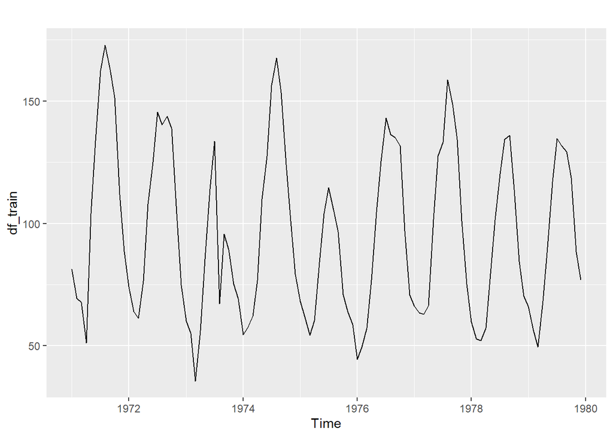

```r
autoplot(df_train)
```

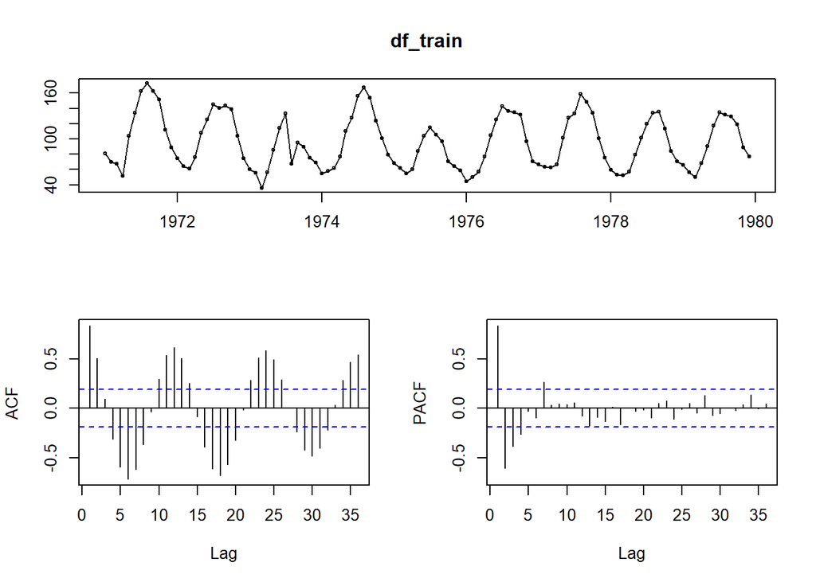

```r
tsdisplay(df_train)
```

As we can see from the plot, the variance seems to be non-constant. Therefore, a box-cox transformation is necessary.

```r
BoxCox.lambda(df_train)
```

```
## [1] -0.3944237
```

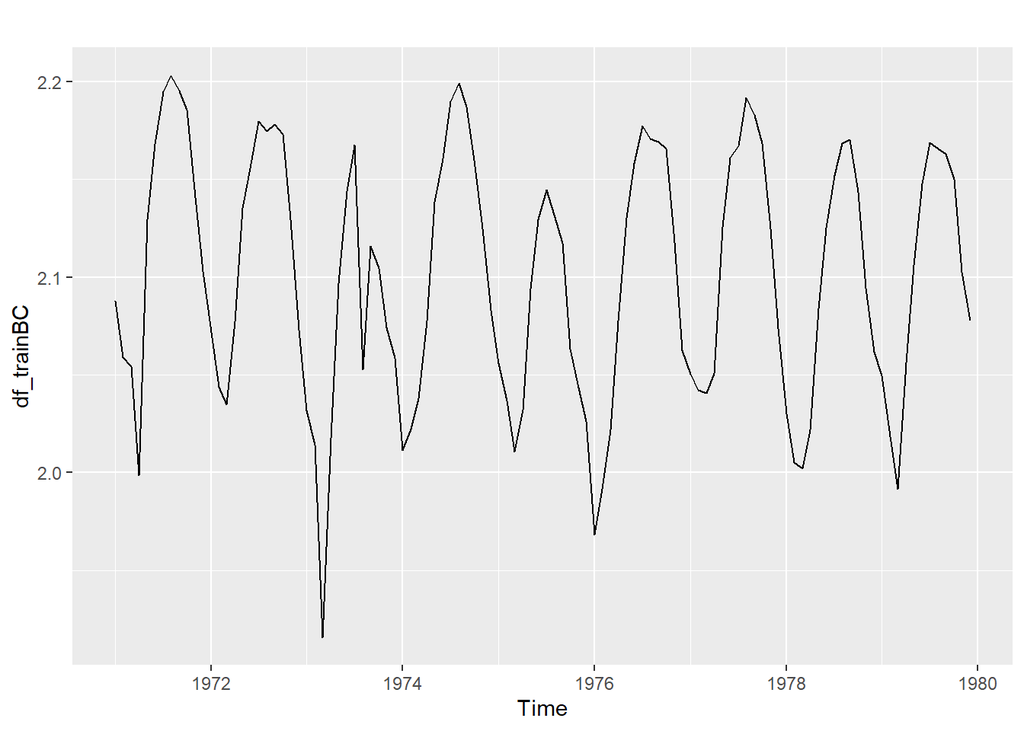

```r
df_trainBC = BoxCox(df_train, lambda =BoxCox.lambda(df_train))
autoplot(df_trainBC)
```

## Question 3:

Is the training dataset stationary? If not, find an appropriate differencing which yields seasonal and trend stationary training dataset. Plot the ACF and PACF to determine if the detrended and deseasonalized time series is stationary.

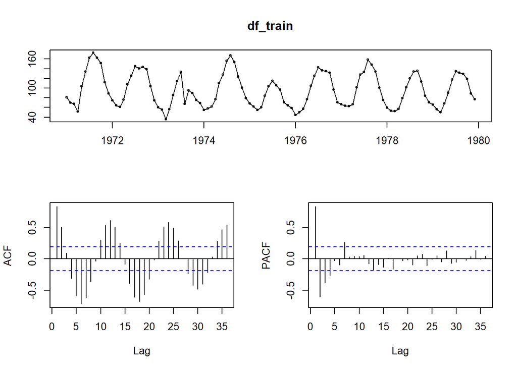

```r
tsdisplay(df_train)
```

• The train dataset is not stationary. Because there are spikes in 12,24,36 and etc. on the ACF plot.

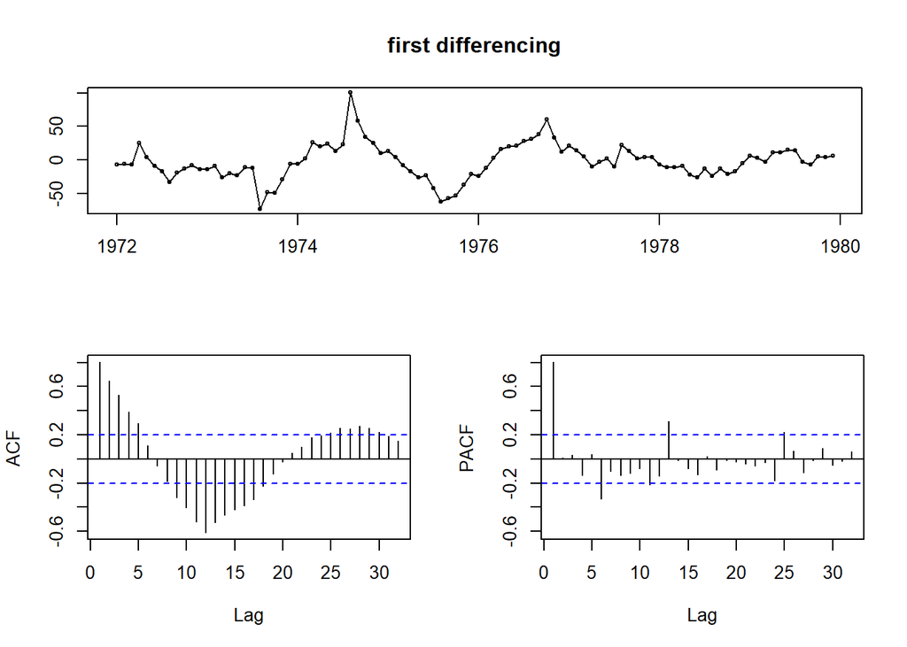

```r
tsdisplay(diff(df_train,lag = 12),main='first differencing')
```

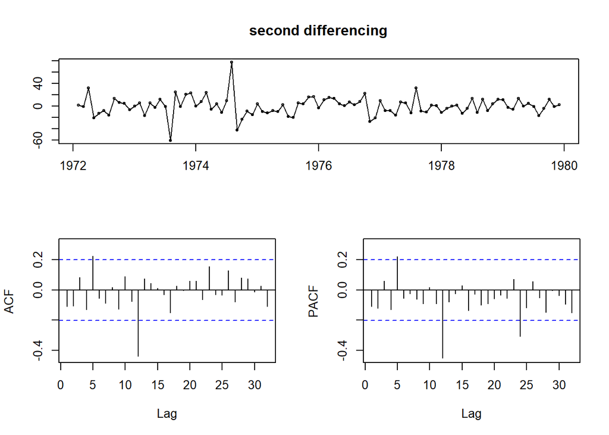

```r
tsdisplay(diff(diff(df_train,lag = 12)),main='second differencing')
```

```r
kpss.test(diff(diff(df_train, lag = 12)))
```

```
##
##  KPSS Test for Level Stationarity
##
## data:  diff(diff(df_train, lag = 12))
## KPSS Level = 0.033903, Truncation lag parameter = 3, p-value = 0.1
```

We can see from the plot that after second differencing, the data becomes stationary. Also the KPSS test shows that the data becomes stationary because the v-value is greater than 0.05, we can not reject the null hypothesis.

## Question 4:

Build two 𝐴𝑅𝐼𝑀𝐴(𝑝, 𝑑, 𝑞)(𝑃,𝑄, 𝐷)𝑠 models using the training dataset and auto.arima() function. • Model 1: Let the auto.arima() function determine the best order of non-seasonal and seasonal differencing.

```r
lambda_value = BoxCox.lambda(df_train)
model1 = auto.arima(df_train,seasonal=TRUE,lambda = lambda_value)
model1
```

```
## Series: df_train
## ARIMA(1,0,0)(2,1,0)[12]
## Box Cox transformation: lambda= -0.3944237
##
## Coefficients:
##         ar1     sar1     sar2
##       0.638  -0.7483  -0.3904
## s.e.  0.081   0.1120   0.1145
##
## sigma^2 = 0.000705:  log likelihood = 209.4
## AIC=-410.81   AICc=-410.37   BIC=-400.55
```

In model1, we have parameters: p = 1, d = 0, q = 0, P = 2, D = 1, Q = 0, AICc = -410.37, BIC = -400.55.

• Model 2: Set the order of seasonal-differencing 𝑑 to 1 and 𝐷 to 1. Report the resulting 𝑝, 𝑑, 𝑞, 𝑃,𝐷,𝑄, 𝑠 and the coefficients values for all cases and compare their AICc and BIC values.

```r
model2 = auto.arima(df_train,d=1,D=1,seasonal=TRUE,lambda = lambda_value)
model2
```

```
## Series: df_train
## ARIMA(1,1,1)(2,1,0)[12]
## Box Cox transformation: lambda= -0.3944237
##
## Coefficients:
##          ar1      ma1     sar1     sar2
##       0.6164  -0.9566  -0.7541  -0.3823
## s.e.  0.1108   0.0638   0.1171   0.1152
##
## sigma^2 = 0.0007327:  log likelihood = 205.13
## AIC=-400.25   AICc=-399.58   BIC=-387.48
```

The AICc and BIC values are both smaller in model1. Therefore, model1 give better results than model2.

## Question 5:

Plot the residuals ACF of both models from part 4 and use the Ljung-Box Test with lag 12 to verify your conclusion.

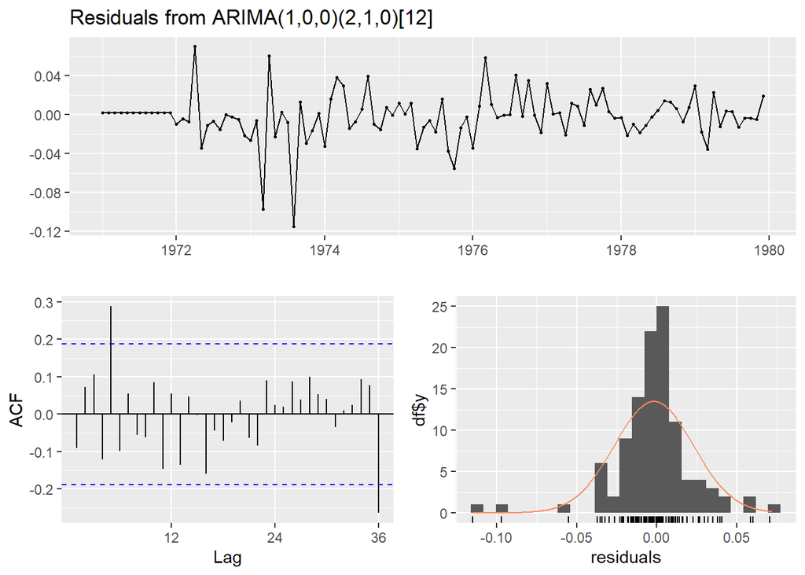

```
##
##  Ljung-Box test
##
## data:  Residuals from ARIMA(1,0,0)(2,1,0)[12]
## Q* = 20.218, df = 9, p-value = 0.01661
##
## Model df: 3.   Total lags used: 12
```

```r
checkresiduals(model1, lag = 12)
```

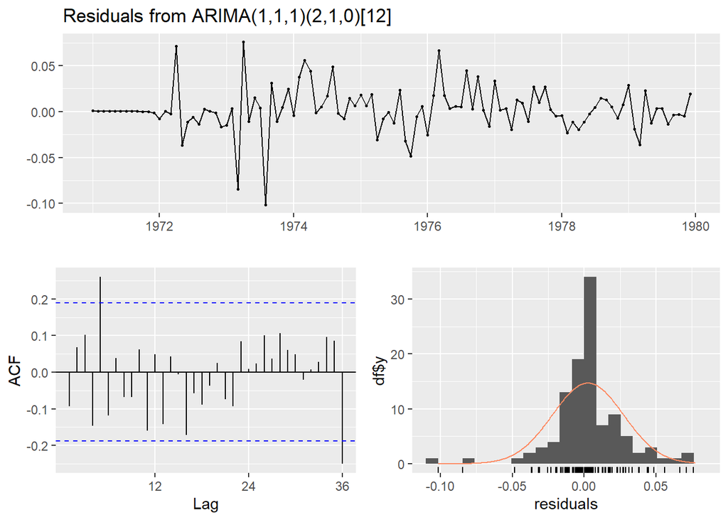

```
##
##  Ljung-Box test
##
## data:  Residuals from ARIMA(1,1,1)(2,1,0)[12]
## Q* = 19.724, df = 8, p-value = 0.01143
##
## Model df: 4.   Total lags used: 12
```

```r
checkresiduals(model2, lag = 12)
```

From the Ljung-Box test, both of the models have a p-value smaller than 0.05. However, p-value of model2 is still smaller than p-value of model1, indicating that the model1 is more possible to have pure white noise.Therefore, it enhanced my conclusion.

## Question 6:

Use both models from part 4 and the h-period argument in the forecast() function to forecast each month of 1980 (i.e., Jan, Feb, …, Dec.) Plot the test dataset and forecasted values.

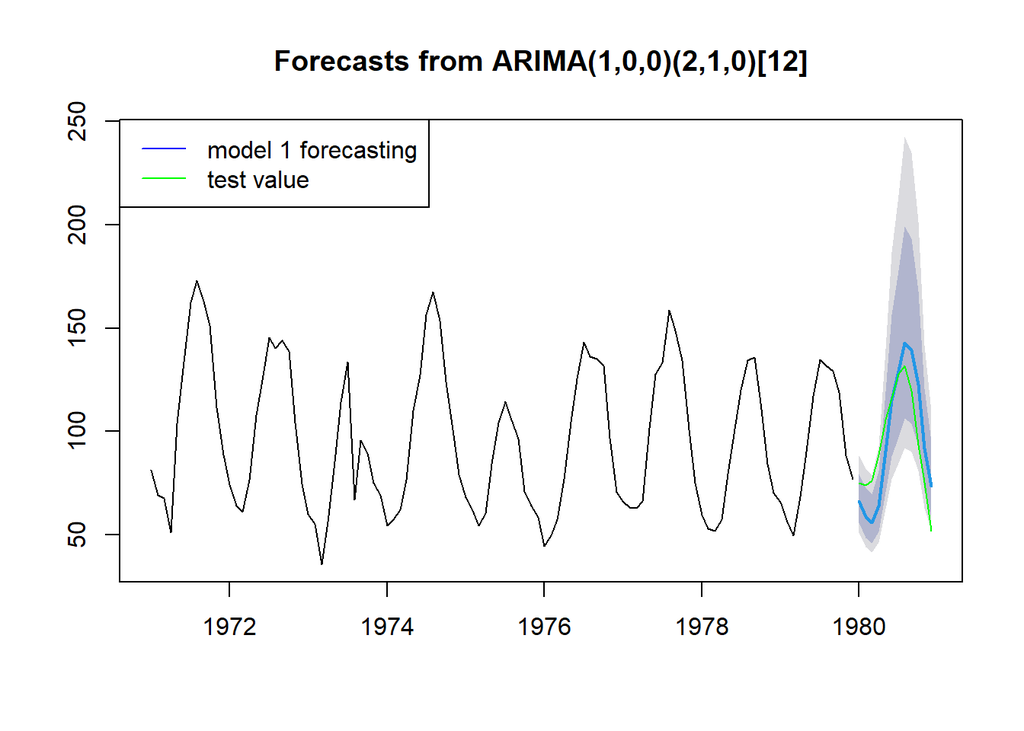

```r
model1_predicted = forecast(model1, h = 12)
test_time <- 1:length(df_test)
plot(model1_predicted)
lines(df_test,col='green')
legend('topleft',legend=c("model 1 forecasting", 'test value'),col=c('blue', 'green'),lty=1)
```

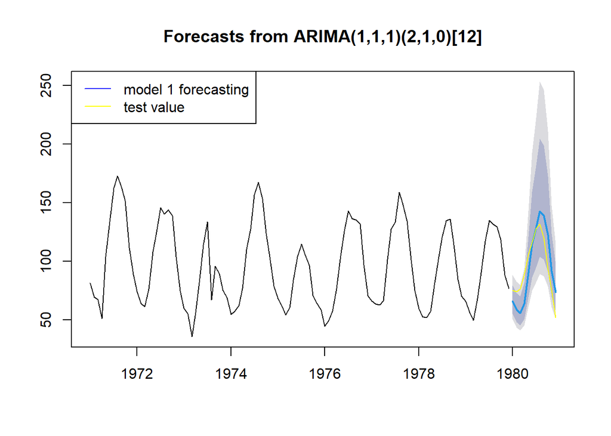

```r
model2_predicted = forecast(model2, h = 12)
test_time <- 1:length(df_test)
plot(model2_predicted)
lines(df_test,col='yellow')
legend('topleft',legend=c("model 1 forecasting", 'test value'),col=c('blue', 'yellow'),lty=1)
```

## Question 7:

Compare the forecast with the actual test data by calculating the Mean Absolute Percentage Error (MAPE) and Mean Squared Error (MSE). Which model is better to forecast the Manufacturer’s Stocks for each month of 1980 (i.e., Jan, Feb, …, Dec)? Why?

```r
model1_mape = MAPE(model1_predicted$mean, df_test)
model2_mape = MAPE(model2_predicted$mean, df_test)
cat("Model 1 MAPE: ", model1_mape, "\n")
```

```
## Model 1 MAPE:  0.1847494
```

```r
cat("Model 2 MAPE: ", model2_mape, "\n")
```

```
## Model 2 MAPE:  0.1851091
```

```r
model1_mse = MSE(model1_predicted$mean, df_test)
model2_mse = MSE(model2_predicted$mean, df_test)
cat("Model 1 MSE: ", model1_mse, "\n")
```

```
## Model 1 MSE:  303.4648
```

```r
cat("Model 2 MSE: ", model2_mse, "\n")
```

```
## Model 2 MSE:  303.4596
```

Model1 has a smaller MAPE, but model2 has a smaller MSE.

- If you prioritize the accuracy of predictions relative to the actual values and aim to minimize the percentage error, Model1, which has a smaller MAPE, would be the preferred choice.
- Conversely, if the magnitude of the errors is of utmost importance and your goal is to minimize the squared differences between the predicted and actual values, then Model2, which has a smaller MSE, would be more suitable.

## Question 8:

Forecast each month of 1980 (i.e., Jan, Feb, …, Dec.) using the seasonal naïve forecast method. Plot the test dataset and forecasted values and compare the forecast with the actual test data by calculating the Mean Absolute Percentage Error (MAPE) and Mean Squared Error (MSE).

[figure not shown]

```r
snaive_predicted = snaive(df_train, h = 12)
test_time <- 1:length(df_test)
plot(model2_predicted)
lines(df_test,col='yellow')
legend('topleft',legend=c("snaive forecasting", 'test value'),col=c('blue', 'yellow'),lty=1)
```

```r
snaive_mape = MAPE(snaive_predicted$mean, df_test)
snaive_mse = MSE(snaive_predicted$mean, df_test)
cat("snaive MAPE: ", snaive_mape, "\n")
```

```
## snaive MAPE:  0.1797548
```

```r
cat("snaive MSE: ", snaive_mse, "\n")
```

```
## snaive MSE:  277.8286
```

## Question 9:

Use the snaive() function to forecast each month of 1980 (i.e., Test Period.) Did your best model beat the seasonal naïve approach?

```r
model1_mape = MAPE(model1_predicted$mean, df_test)
model2_mape = MAPE(model2_predicted$mean, df_test)

model1_mse = MSE(model1_predicted$mean, df_test)
model2_mse = MSE(model2_predicted$mean, df_test)

snaive_mape = MAPE(snaive_predicted$mean, df_test)
snaive_mse = MSE(snaive_predicted$mean, df_test)

cat("Model 1 MAPE: ", model1_mape, "\n")
```

```
## Model 1 MAPE:  0.1847494
```

```r
cat("Model 2 MAPE: ", model2_mape, "\n")
```

```
## Model 2 MAPE:  0.1851091
```

```r
cat("snaive MAPE: ", snaive_mape, "\n")
```

```
## snaive MAPE:  0.1797548
```

```r
cat("Model 1 MSE: ", model1_mse, "\n")
```

```
## Model 1 MSE:  303.4648
```

```r
cat("Model 2 MSE: ", model2_mse, "\n")
```

```
## Model 2 MSE:  303.4596
```

```r
cat("snaive MSE: ", snaive_mse, "\n")
```

```
## snaive MSE:  277.8286
```

Since the snaive model generate the lowest MAPE and MSE, my best model did not beat the seasonal naive approch.